# Enrichment

RAJ LAB

Most Recent Update: 2019-08-22

```r
source("echolocatoR/R/MAIN.R")
library(dplyr)
library(plotly)
```

# Fine-mapping Summaries

- First, we gather annotations from HaploReg and/or Biomart and assess the distribtuion of differenrt SNP Groups (e.g. GWAS lead SNPs, Credible Sets, Consensus SNPs).

```r
merged_results <- merge_finemapping_results(minimum_support=1,
                                            include_leadSNPs=T,
                                            xlsx_path="./Data/annotated_finemapping_results.xlsx",
                                            from_storage=T,
                                            haploreg_annotation=T,
                                            biomart_annotation=T,
                                            verbose = F)
```

```
## [1] "++ Submitting chunk 1 / 1"
```

```
## Note: zip::zip() is deprecated, please use zip::zipr() instead
```

```r
merged_results <- subset(merged_results, Dataset=="./Data/GWAS/Nalls23andMe_2019")
createDT(subset(merged_results, Support == 2))
```

|  | SNP | Dataset | Gene | CHR | POS | P | Effect | StdErr | A1 | A2 | leadSNP | SUSIE.Credible_Set | SUSIE.Probability | FINEMAP.Credible_Set | FINEMAP.Probability | Consensus_SNP | Support | Freq | MAF | N_cases | N_controls | proportion_cases | chr | pos_hg38 | r2 | D' | is_query_snp | ref | alt | … |
| --- | --- | --- | --- | --- | --- | --- | --- | --- | --- | --- | --- | --- | --- | --- | --- | --- | --- | --- | --- | --- | --- | --- | --- | --- | --- | --- | --- | --- | --- | --- |
| 1 | rs10797576 | ./Data/GWAS/Nalls23andMe_2019 | SIPA1L2 | 1 | 232664611 | 6.84e-17 | 0.1114 | 0.0133 | T | C | True | 4 | 1 | 1 | 1 | True | 2 | 0.1403 | 0.1403 | 56306 | 1417791 | 0.0381969436203995 | 1 | 232528865 | 0 | 0 | 0 | C | T | … |
| 2 | rs10810837 | ./Data/GWAS/Nalls23andMe_2019 | SH3GL2 | 9 | 17730965 | 1.516e-16 | -0.0901 | 0.0109 | T | C | False | 2 | 1 | 1 | 1 | True | 2 | 0.7618 | 0.2382 | 56306 | 1417791 | 0.0381969436203995 | 9 | 17730967 | 0 | 0 | 0 | T | C | … |
| 3 | rs10847839 | ./Data/GWAS/Nalls23andMe_2019 | HIP1R | 12 | 123322560 | 7.197e-33 | -0.1467 | 0.0123 | T | C | False | 2 | 1 | 1 | 1 | True | 2 | 0.6322 | 0.3678 | 42598 | 1322509 | 0.0312048799105125 | 12 | 122838013 | 0 | 0 | 0 | T | C | … |
| 4 | rs10847839 | ./Data/GWAS/Nalls23andMe_2019 | HIP1R | 12 | 123322560 | 7.197e-33 | -0.1467 | 0.0123 | T | C | False | 2 | 1 | 1 | 1 | True | 2 | 0.6322 | 0.3678 | 42598 | 1322509 | 0.0312048799105125 | 12 | 122838013 | 0 | 0 | 0 | T | C | … |
| 5 | rs10847864 | ./Data/GWAS/Nalls23andMe_2019 | HIP1R | 12 | 123326598 | 1.467e-37 | 0.1478 | 0.0115 | T | G | True | 3 | 1 | 1 | 1 | True | 2 | 0.364 | 0.364 | 56306 | 1417791 | 0.0381969436203995 | 12 | 122842051 | 0 | 0 | 0 | G | T | … |
| 6 | rs10847864 | ./Data/GWAS/Nalls23andMe_2019 | HIP1R | 12 | 123326598 | 1.467e-37 | 0.1478 | 0.0115 | T | G | True | 3 | 1 | 1 | 1 | True | 2 | 0.364 | 0.364 | 56306 | 1417791 | 0.0381969436203995 | 12 | 122842051 | 0 | 0 | 0 | G | T | … |
| 7 | rs11057293 | ./Data/GWAS/Nalls23andMe_2019 | HIP1R | 12 | 122740810 | 0.6808 | 0.0214 | 0.052 | C | G | False | 1 | 1 | 1 | 1 | True | 2 | 0.0178 | 0.0178 | 42598 | 1322509 | 0.0312048799105125 | 12 | 122256263 | 0 | 0 | 0 | G | C | … |
| 8 | rs11057293 | ./Data/GWAS/Nalls23andMe_2019 | HIP1R | 12 | 122740810 | 0.6808 | 0.0214 | 0.052 | C | G | False | 1 | 1 | 1 | 1 | True | 2 | 0.0178 | 0.0178 | 42598 | 1322509 | 0.0312048799105125 | 12 | 122256263 | 0 | 0 | 0 | G | C | … |
| 9 | rs11057293 | ./Data/GWAS/Nalls23andMe_2019 | HIP1R | 12 | 122740810 | 0.6808 | 0.0214 | 0.052 | C | G | False | 1 | 1 | 1 | 1 | True | 2 | 0.0178 | 0.0178 | 42598 | 1322509 | 0.0312048799105125 | 12 | 122256263 | 0 | 0 | 0 | G | C | … |
| 10 | rs11057293 | ./Data/GWAS/Nalls23andMe_2019 | HIP1R | 12 | 122740810 | 0.6808 | 0.0214 | 0.052 | C | G | False | 1 | 1 | 1 | 1 | True | 2 | 0.0178 | 0.0178 | 42598 | 1322509 | 0.0312048799105125 | 12 | 122256263 | 0 | 0 | 0 | G | C | … |

[output cut: 131 more lines]

## Mutation Types

```r
potential_missense <- SNPs_by_mutation_type(merged_results, mutation_type="missense_variant")
createDT(potential_missense)
```

|  | Dataset | Gene | SNP | consequence_type_tv |
| --- | --- | --- | --- | --- |
| 1 | ./Data/GWAS/Nalls23andMe_2019 | TRIM40 | rs1265096 | non_coding_transcript_variant |
| 2 | ./Data/GWAS/Nalls23andMe_2019 | TRIM40 | rs1265096 | intron_variant |
| 3 | ./Data/GWAS/Nalls23andMe_2019 | TRIM40 | rs1265096 | missense_variant |
| 4 | ./Data/GWAS/Nalls23andMe_2019 | TRIM40 | rs1265096 | non_coding_transcript_exon_variant |
| 5 | ./Data/GWAS/Nalls23andMe_2019 | TRIM40 | rs1265096 | 5_prime_UTR_variant |
| 6 | ./Data/GWAS/Nalls23andMe_2019 | TRIM40 | rs2233952 | non_coding_transcript_variant |
| 7 | ./Data/GWAS/Nalls23andMe_2019 | TRIM40 | rs2233952 | intron_variant |
| 8 | ./Data/GWAS/Nalls23andMe_2019 | TRIM40 | rs2233952 | missense_variant |
| 9 | ./Data/GWAS/Nalls23andMe_2019 | CD19 | rs2904880 | intron_variant |
| 10 | ./Data/GWAS/Nalls23andMe_2019 | CD19 | rs2904880 | missense_variant |

[output cut: 11 more lines]

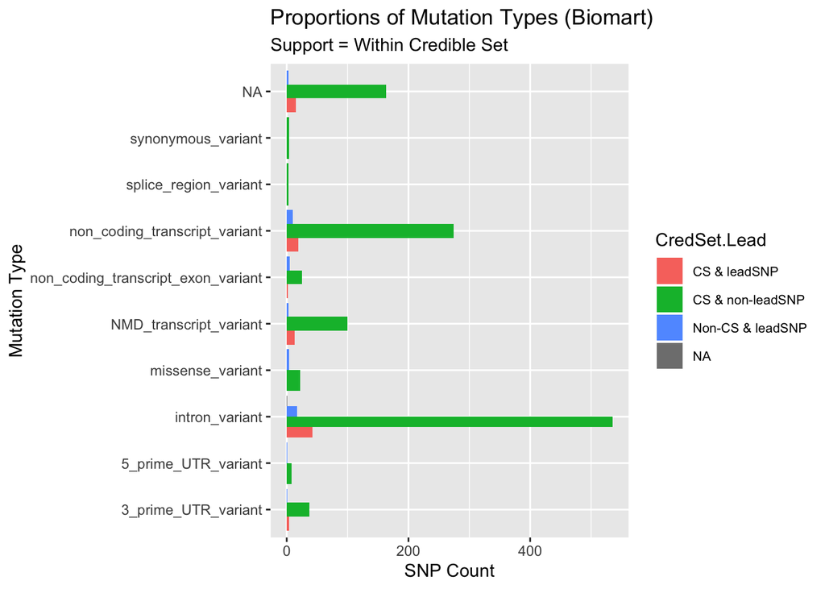

```r
# candidate_counts <- counts_summary(top_SNPs, merged_results)
# createDT(candidate_counts)

# Distribution of mutation types in Credible Set SNPs
mod <- merged_results %>%
  mutate(CredSet.Lead =
           ifelse(Support>0,
                  ifelse(leadSNP==T,"CS & leadSNP", "CS & non-leadSNP"),
                  ifelse(leadSNP==T, "Non-CS & leadSNP","Non-CS & non-leadSNP")),NA)
ggplot(data=mod, aes(x=consequence_type_tv, fill=CredSet.Lead)) +
  geom_bar(aes(y = ..count..), position="dodge") + # (..count..)/sum(..count..)
  coord_flip() +
  labs(title="Proportions of Mutation Types (Biomart)",
       subtitle = "Support = Within Credible Set",
       x = "Mutation Type",
       y="SNP Count") +
  theme(legend.text = element_text(size=8))
```

# psychENCODE

- Results from the psychENCODE project have been [published](https://science.sciencemag.org/content/362/6420/eaat8464) and the [data made available](http://resource.psychencode.org/?_ga=2.202944787.381602893.1563834178-1901423550.1563307711).
- We perform an inital assesment of what percentage of each SNP Group contains expression, isoform, or chromatin QTLs (e/iso/cQTL).

```r
psychENCODE.download_summary_stats()
```

```
## [1] "psychENCODE:: Downloading summary stats."
## [1] "psychENCODE:: File already exists."
## [1] "psychENCODE:: File already exists."
## [1] "psychENCODE:: File already exists."
## [1] "psychENCODE:: File already exists."
```

```r
percent_df <- psychENCODE.assay_summary()
```

```
## [1] "+ Gathering all fine-mapping results from storage..."
## [1] "+ Importing results... PTK2B"
## [1] "+ Importing results... ASXL3"
## [1] "+ Importing results... ATG14"
## [1] "+ Importing results... ATP6V0A1"
## [1] "+ Importing results... BIN3"
## [1] "+ Importing results... BRIP1"
## [1] "+ Importing results... BST1"
## [1] "+ Importing results... C5orf24"
## [1] "+ Importing results... CAB39L"
## [1] "+ Importing results... CAMK2D"
## [1] "+ Importing results... CASC16"
## [1] "+ Importing results... CD19"
## [1] "+ Importing results... CHD9"
## [1] "+ Importing results... CHRNB1"
```

[output cut: 488 more lines]

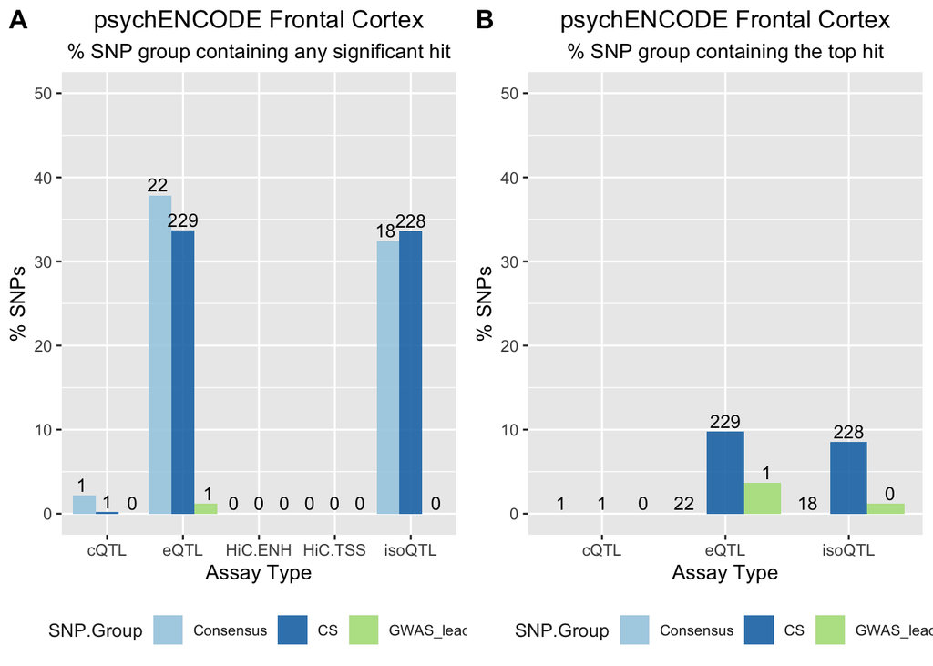

```r
psychENCODE.overlap_plots(percent_df)
```

# fGWAS

- fGWAS is designed to take all signficant SNPs from a GWAS and test for enrichment of various functional (e.g. DNAase hit, chromatin peak), genic (e.g. synonymous, noncoding) and/or distance (e.g.) annotations.
- Here we use fGWAS to test for enrichment amongst three different groups of SNPs:
  1. **lead SNPs**: The top SNP (sorted by GWAS FDR) from each locus in the original GWAS.
  2. **Credible Set SNPs**: SNPs that were identified by at least one fine-mapping tool.
  3. **Consensus SNPs**: SNPs that were identified by ALL fine-mapping tools tested.
- We use enrichment as a way to tell us whether our fine-mapping is working, i.e. it’s identifying SNPs that are more functionally releveant and thus more likely to play a role in the phenotype (e.g. Parksinon’s).
  - Specifically, we are using the 451 pre-formatted annotations found [here](https://github.com/joepickrell/fgwas)

## Run fGWAS

```r
results.DF <- fgwas(results_path="./Data/GWAS/Nalls23andMe_2019/_genome_wide",
                    fgwas.out = file.path(results_path,"fGWAS","Output"),
                    fgwas = "./echolocatoR/tools/fgwas-0.3.6/src/fgwas",
                    dataset = "./Data/GWAS/Nalls23andMe_2019",
                    remove_tmps = T,
                    force_new_fgwas = F)
```

```
## [1] "fGWAS:: Results file already exists."
## [1] "  Importing:  ./Data/GWAS/Nalls23andMe_2019/_genome_wide/fGWAS/fGWAS_summary.Nalls23andMe_2019.txt"
```

```r
createDT(results.DF)
```

|  | llk.file | SNP.Group | Annot | params.file | ln(lk): | nparam: | AIC: | parameter | CI_lo | CI_hi | estimate |
| --- | --- | --- | --- | --- | --- | --- | --- | --- | --- | --- | --- |
| 1 | Consensus__A549-DS14289.hotspot.twopass.fdr0.05.merge.llk | Consensus | A549-DS14289 | Consensus__A549-DS14289.hotspot.twopass.fdr0.05.merge.params | -225.702 | 1 | 453.403 | A549-DS14289.hotspot.twopass.fdr0.05.merge_ln | &lt;-81 | &gt;20 | -61 |
| 2 | Consensus__AG04449-DS12319.hotspot.twopass.fdr0.05.merge.llk | Consensus | AG04449-DS12319 | Consensus__AG04449-DS12319.hotspot.twopass.fdr0.05.merge.params | -225.707 | 1 | 453.414 | AG04449-DS12319.hotspot.twopass.fdr0.05.merge_ln | &lt;-20 | &gt;20 | 1 |
| 3 | Consensus__AG04450-DS12270.hotspot.twopass.fdr0.05.merge.llk | Consensus | AG04450-DS12270 | Consensus__AG04450-DS12270.hotspot.twopass.fdr0.05.merge.params | -225.707 | 1 | 453.414 | AG04450-DS12270.hotspot.twopass.fdr0.05.merge_ln | &lt;-20 | &gt;20 | 1 |
| 4 | Consensus__AG09309-DS12352.hotspot.twopass.fdr0.05.merge.llk | Consensus | AG09309-DS12352 | Consensus__AG09309-DS12352.hotspot.twopass.fdr0.05.merge.params | -225.707 | 1 | 453.414 | AG09309-DS12352.hotspot.twopass.fdr0.05.merge_ln | &lt;-20 | &gt;20 | 1 |
| 5 | Consensus__AG09319-DS12291.hotspot.twopass.fdr0.05.merge.llk | Consensus | AG09319-DS12291 | Consensus__AG09319-DS12291.hotspot.twopass.fdr0.05.merge.params | -225.707 | 1 | 453.414 | AG09319-DS12291.hotspot.twopass.fdr0.05.merge_ln | &lt;-20 | &gt;20 | 1 |
| 6 | Consensus__AG10803-DS12384.hotspot.twopass.fdr0.05.merge.llk | Consensus | AG10803-DS12384 | Consensus__AG10803-DS12384.hotspot.twopass.fdr0.05.merge.params | -225.707 | 1 | 453.414 | AG10803-DS12384.hotspot.twopass.fdr0.05.merge_ln | &lt;-20 | &gt;20 | 1 |
| 7 | Consensus__AoAF-DS13523.hotspot.twopass.fdr0.05.merge.llk | Consensus | AoAF-DS13523 | Consensus__AoAF-DS13523.hotspot.twopass.fdr0.05.merge.params | -225.707 | 1 | 453.414 | AoAF-DS13523.hotspot.twopass.fdr0.05.merge_ln | &lt;-20 | &gt;20 | 1 |
| 8 | Consensus__BE2_C-DS14625.hotspot.twopass.fdr0.05.merge.llk | Consensus | BE2_C-DS14625 | Consensus__BE2_C-DS14625.hotspot.twopass.fdr0.05.merge.params | -225.707 | 1 | 453.414 | BE2_C-DS14625.hotspot.twopass.fdr0.05.merge_ln | &lt;-20 | &gt;20 | 1 |
| 9 | Consensus__BJ-DS10081.hotspot.twopass.fdr0.05.merge.llk | Consensus | BJ-DS10081 | Consensus__BJ-DS10081.hotspot.twopass.fdr0.05.merge.params | -225.702 | 1 | 453.403 | BJ-DS10081.hotspot.twopass.fdr0.05.merge_ln | &lt;-81 | &gt;20 | -61 |
| 10 | Consensus__CACO2-DS8235.hotspot.twopass.fdr0.05.merge.llk | Consensus | CACO2-DS8235 | Consensus__CACO2-DS8235.hotspot.twopass.fdr0.05.merge.params | -225.707 | 1 | 453.414 | CACO2-DS8235.hotspot.twopass.fdr0.05.merge_ln | &lt;-20 | &gt;20 | 1 |

[output cut: 1337 more lines]

## Plot fGWAS

- Each of the enrichment test results (451 annotations x 3 SNP Groups) were grouped according to their *estimate* (i.e. their enrichment score). No tests yielded and estimate of 0:
  - **Enriched**: `estimate > 0`
  - **Depleted**: `estimate < 0`
- When `interact=T`, hover to explore more information about each data point, including the annotation that the enirchment test was conducted with.

```r
bp <- fgwas.boxplot(results.DF, interact=T)
print(bp)
```

[output not shown]

- Estimates are averaged by tissue here.
- You can also view each annotation as a separate row by selecting `annotation_or_tissue = "annotation`.
  - In this view, additional metadata variables can be explored on the right side columns.

```r
# By Tissue
hm <- fgwas.heatmap(results.DF, annotation_or_tissue = "tissue")
print(hm)
# By Annotation
hm <- fgwas.heatmap(results.DF, annotation_or_tissue = "annotation")
print(hm)
```

[output not shown]

# GoShifter

**GoShifter**: Performs SNP-level enrichment tests using BED files. However, unlike simpler methods, it also incorporates Linkage Disequilibrium (LD) info into the model. In this pipeline, LD is estimated from the refrence panel (e.g. 1000 Genomes Phase 1). + Because GoShifter does not consider a specific background, these tests were repeated for both the Credible Sets, and then in all the SNPs in the same locus. - GoShifter was used to test for enrichment in three different SNP Groups:  
1. **Credible Set**: SNPs that were prioritized by at least one fine-mapping tool. 2. **Lead SNPs**: The top N significant SNPs in the original GWAS, where N is equal to the number of Credible Set SNPs. 3. **Random**: A randomly chosen numer of SNPs

- Plots:
  - **Histograms**: For each enrichment test, GoShifter produces a p-value. However in the documentation they state that p-value is calculated accordingly: *“P-value is the number of times the “enrichment” is greater or equal to the observed overlap divided by total number of permutations."*
  - This can be written as:`sum(enrichment >= nSnpOverlap) / n.permutations`
  - However, the given p-value (GS.pval) and the calculated p.value (pval) differ quite a lot, and I’m not sure why this is.

## Prepare Data

```r
# List all chromatin state options
chrom.states.df <- GoShifter.list_chromatin_states()
createDT(chrom.states.df)
```

|  | STATE NO. | MNEMONIC | DESCRIPTION | COLOR NAME | COLOR CODE |
| --- | --- | --- | --- | --- | --- |
| 1 | 1 | TssA | Active TSS | Red | 255,0,0 |
| 2 | 2 | TssFlnk | Flanking TSS | Orange Red | 255,69,0 |
| 3 | 3 | TssFlnkU | Flanking TSS Upstream | Orange Red | 255,69,0 |
| 4 | 4 | TssFlnkD | Flanking TSS Downstream | Orange Red | 255,69,0 |
| 5 | 5 | Tx | Strong transcription | Green | 0,128,0 |
| 6 | 6 | TxWk | Weak transcription | DarkGreen | 0,100,0 |
| 7 | 7 | EnhG1 | Genic enhancer1 | GreenYellow | 194,225,5 |
| 8 | 8 | EnhG2 | Genic enhancer2 | GreenYellow | 194,225,5 |
| 9 | 9 | EnhA1 | Active Enhancer 1 | Orange | 255,195,77 |
| 10 | 10 | EnhA2 | Active Enhancer 2 | Orange | 255,195,77 |

[output cut: 8 more lines]

```r
# Prepare Data
results_path <- "./Data/GWAS/Nalls23andMe_2019/LRRK2"
finemap_DT <- data.table::fread(file.path(results_path,"Multi-finemap/Multi-finemap_results.txt"))
# Create different subsets of SNPs to test for enrichment
snp_df.CS <- subset(finemap_DT, Support>0)
snp_df.GWAS <- (finemap_DT %>% dplyr::arrange(P, desc(Effect)))[1:nrow(snp_df.CS),]
snp_df.Random <- finemap_DT[sample(nrow(finemap_DT), nrow(snp_df.CS)), ]
snp.df.list <- list("CS"=snp_df.CS, "GWAS"=snp_df.GWAS, "Random"=snp_df.Random)
```

```r
# Iterate GoShifter over each SNP Group
GS.groups <- lapply(names(snp.df.list), function(group){
  printer("GoShifter:: testing enrichment for SNP Group:",group)
  GS.RESULTS <- GoShifter(results_path = results_path,
                           snp_df = snp.df.list[[group]],
                           SNP.Group = group,
                           ROADMAP_search = c("monocyte","brain"),
                           ROADMAP_type = c("PrimaryCell","PrimaryTissue"),
                           chromatin_states = c("TssA","Quies"),#NA,
                           R2_filter = 0.8, # Include LD SNPs at rsquared >= NUM [default: 0.8]
                           overlap_threshold = 1,
                           remove_tmps = F,
                           force_new_goshifter = F)
  GS.RESULTS$SNP.Group <- group
  return(GS.RESULTS)
}) %>% data.table::rbindlist()
```

```
## [1] "GoShifter:: testing enrichment for SNP Group: CS"
## [1] "++ GoShifter: Creating snpmap file..."
## [1] "+++ snpmap written to : ./Data/GWAS/Nalls23andMe_2019/LRRK2/GoShifter/snpmap.txt"
## [1] "++ GoShifter: Creating LD file(s)..."
## [1] "+++ LD file(s) written to : ./Data/GWAS/Nalls23andMe_2019/LRRK2/GoShifter/LD"
## [1] "++ GoShifter: Searching for Roadmap annotation BED files..."
## [1] "++ GoShifter: Found 15 annotation BED files matching search query."
## [1] "GoShifter:: testing enrichment for SNP Group: GWAS"
## [1] "++ GoShifter: Creating snpmap file..."
## [1] "+++ snpmap written to : ./Data/GWAS/Nalls23andMe_2019/LRRK2/GoShifter/snpmap.txt"
## [1] "++ GoShifter: Creating LD file(s)..."
## [1] "+++ LD file(s) written to : ./Data/GWAS/Nalls23andMe_2019/LRRK2/GoShifter/LD"
## [1] "++ GoShifter: Searching for Roadmap annotation BED files..."
## [1] "++ GoShifter: Found 15 annotation BED files matching search query."
## [1] "GoShifter:: testing enrichment for SNP Group: Random"
## [1] "++ GoShifter: Creating snpmap file..."
## [1] "+++ snpmap written to : ./Data/GWAS/Nalls23andMe_2019/LRRK2/GoShifter/snpmap.txt"
## [1] "++ GoShifter: Creating LD file(s)..."
## [1] "+++ LD file(s) written to : ./Data/GWAS/Nalls23andMe_2019/LRRK2/GoShifter/LD"
## [1] "++ GoShifter: Searching for Roadmap annotation BED files..."
## [1] "++ GoShifter: Found 15 annotation BED files matching search query."
```

```r
createDT(head(GS.groups))
```

|  | EID | locus | overlap | score | Annotation | GROUP | ANATOMY | GR | Epigenome.Mnemonic | Standardized.Epigenome.name | Epigenome.name | TYPE | pval | mean.nSnpOverlap | allSnps | mean.enrichment | chromatin_state | GS.pval | SNP.Group |
| --- | --- | --- | --- | --- | --- | --- | --- | --- | --- | --- | --- | --- | --- | --- | --- | --- | --- | --- | --- |
| 1 | E067 | rs12422278 |  |  | E067_TssA_subset.bed.gz | Brain | BRAIN | Brain | BRN.ANG.GYR | Brain Angular Gyrus | Brain_Angular_Gyrus | PrimaryTissue | 0.019 | 2.80619380619381 | 11 | 0.255111078921079 | TssA | 0.867 | CS |
| 2 | E067 | rs117891010 |  |  | E067_TssA_subset.bed.gz | Brain | BRAIN | Brain | BRN.ANG.GYR | Brain Angular Gyrus | Brain_Angular_Gyrus | PrimaryTissue | 0.019 | 2.80619380619381 | 11 | 0.255111078921079 | TssA | 0.867 | CS |
| 3 | E067 | rs76904798 |  |  | E067_TssA_subset.bed.gz | Brain | BRAIN | Brain | BRN.ANG.GYR | Brain Angular Gyrus | Brain_Angular_Gyrus | PrimaryTissue | 0.019 | 2.80619380619381 | 11 | 0.255111078921079 | TssA | 0.867 | CS |
| 4 | E067 | rs17466626 |  |  | E067_TssA_subset.bed.gz | Brain | BRAIN | Brain | BRN.ANG.GYR | Brain Angular Gyrus | Brain_Angular_Gyrus | PrimaryTissue | 0.019 | 2.80619380619381 | 11 | 0.255111078921079 | TssA | 0.867 | CS |
| 5 | E067 | rs11564266 |  |  | E067_TssA_subset.bed.gz | Brain | BRAIN | Brain | BRN.ANG.GYR | Brain Angular Gyrus | Brain_Angular_Gyrus | PrimaryTissue | 0.019 | 2.80619380619381 | 11 | 0.255111078921079 | TssA | 0.867 | CS |
| 6 | E067 | rs76664306 |  |  | E067_TssA_subset.bed.gz | Brain | BRAIN | Brain | BRN.ANG.GYR | Brain Angular Gyrus | Brain_Angular_Gyrus | PrimaryTissue | 0.019 | 2.80619380619381 | 11 | 0.255111078921079 | TssA | 0.867 | CS |

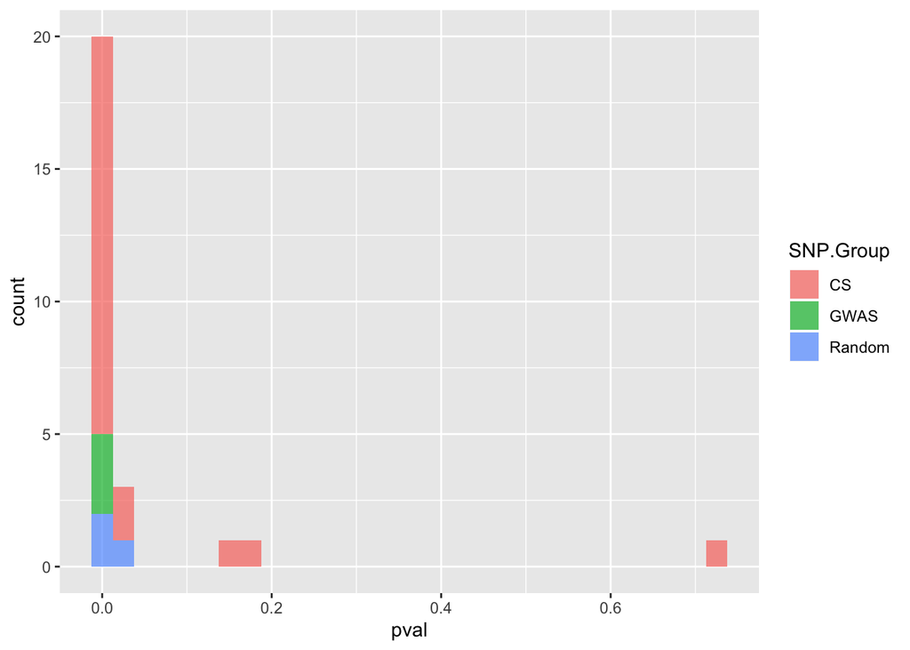

```r
# GoShifter.histograms(GS_results_CS)
hst <- GoShifter.histograms_SNPgroups(GS.groups)
```

```r
hm <- GoShifter.heatmap(GS.groups)
print(hm)
```

[output not shown]